# Space Data Project

Author

Group 3

# Overview

> This project analyzes the *Space Missions* dataset, which tracks rocket launches worldwide from 1957 to August 2022. Our team examined various components of space travel, including mission outcomes, which companies led the launch, rocket types, the country involved, and how mission success has evolved over time. In particular, we were interested in exploring the reliability of machinery and how different establishments and countries have individually contributed to space travel. This topic is intriguing because it depicts technological advancement and growing contribution to space exploration across the globe.

# Wrangling

> Our dataset was produced by Saikat Panja on Kaggle and imported into RStudio as a CSV file. It includes comprehensive data from global space missions ranging from 1957 to 2022. For the *Price* variable, missing values were kept as ‘NA’, as the cost was unknown for a majority of the space missions in the raw data.

#### Variables in Dataset:

# Tibble

```r
library(tidyverse)
library (gt)

space_data <- read_csv("space_missions.csv", locale = locale(encoding = "ISO-8859-1"))
# added to standardize French company name
space_data
```

```
# A tibble: 4,630 × 9
   Company   Location         Date       Time  Rocket Mission RocketStatus Price
   <chr>     <chr>            <date>     <tim> <chr>  <chr>   <chr>        <dbl>
 1 RVSN USSR Site 1/5, Baiko… 1957-10-04 19:28 Sputn… Sputni… Retired         NA
 2 RVSN USSR Site 1/5, Baiko… 1957-11-03 02:30 Sputn… Sputni… Retired         NA
 3 US Navy   LC-18A, Cape Ca… 1957-12-06 16:44 Vangu… Vangua… Retired         NA
 4 AMBA      LC-26A, Cape Ca… 1958-02-01 03:48 Juno I Explor… Retired         NA
 5 US Navy   LC-18A, Cape Ca… 1958-02-05 07:33 Vangu… Vangua… Retired         NA
 6 AMBA      LC-26A, Cape Ca… 1958-03-05 18:27 Juno I Explor… Retired         NA
 7 US Navy   LC-18A, Cape Ca… 1958-03-17 12:15 Vangu… Vangua… Retired         NA
 8 AMBA      LC-5, Cape Cana… 1958-03-26 17:38 Juno I Explor… Retired         NA
 9 RVSN USSR Site 1/5, Baiko… 1958-04-27 09:01 Sputn… Sputni… Retired         NA
10 US Navy   LC-18A, Cape Ca… 1958-04-28 02:53 Vangu… Vangua… Retired         NA
# ℹ 4,620 more rows
# ℹ 1 more variable: MissionStatus <chr>
```

# Tables

## Successful Missions by Company

```r
company_success <- space_data |>
  filter(MissionStatus == "Success") |>
  count(Company) |>
  arrange(desc(n)
    ) |>
  gt() |>
  tab_header(
    title = md("**Successful Missions by Company**"),
    subtitle = "Number of Successful Launches"
  ) |>
  cols_label(
    Company = "Company",
    n = "Successes"
    ) |>
  tab_source_note(
    source_note = md("Data from the Space Missions dataset by Saikat Panja.")
  ) |>
  tab_options(table.width = pct(100))
company_success
```

**Successful Missions by Company**

Number of Successful Launches

| Company | Successes |
| --- | --- |
| RVSN USSR | 1614 |
| CASC | 318 |
| Arianespace | 282 |
| General Dynamics | 203 |
| VKS RF | 202 |
| NASA | 186 |
| SpaceX | 172 |
| ULA | 150 |
| Boeing | 131 |
| US Air Force | 129 |
| Martin Marietta | 100 |
| MHI | 83 |
| Northrop | 80 |
| Lockheed | 74 |
| ISRO | 68 |
| Roscosmos | 64 |
| ILS | 45 |
| Sea Launch | 33 |
| ISAS | 26 |
| Rocket Lab | 25 |
| Blue Origin | 21 |
| Kosmotras | 21 |
| Eurockot | 12 |
| ExPace | 12 |
| ESA | 10 |
| Starsem | 10 |
| ASI | 9 |
| IAI | 9 |
| JAXA | 7 |
| CNES | 6 |
| Land Launch | 6 |
| MITT | 6 |
| ISA | 5 |
| AMBA | 4 |
| CASIC | 4 |
| Virgin Orbit | 4 |
| Armée de l'Air | 3 |
| Astra | 2 |
| Galactic Energy | 2 |
| IRGC | 2 |
| KARI | 2 |
| KCST | 2 |
| OKB-586 | 2 |
| SRC | 2 |
| US Navy | 2 |
| Virgin Galactic | 2 |
| Yuzhmash | 2 |
| CAS Space | 1 |
| CECLES | 1 |
| Douglas | 1 |
| GK LS | 1 |
| Khrunichev | 1 |
| RAE | 1 |
| UT | 1 |
| i-Space | 1 |

Data from the Space Missions dataset by Saikat Panja.

> This table displays the number of successful mission outcomes by organization and was chosen to provide a comprehensive overview of launch success across companies. Mission status was filtered to show only successful launches and arranged in descending order to display companies with the greatest number of successful missions at the top. This allows RVSN USSR to be clearly identified as the dominant organization in regard to launch success.

## Rocket Success Rate by Country

```r
library(tidyverse)
library(gt)

## Processing data
space_missions <-
  read_csv("space_missions.csv") |>
  mutate(
    Country = str_extract(
      Location,
      pattern = "(?<=,)[^,]*$"))

## Summarizing the counts
summary_table <-
  space_missions |>
  group_by(Country, MissionStatus) |>
  summarise(Count = n(), .groups = 'drop') |>
  pivot_wider(
    names_from = MissionStatus,
    values_from = Count,
    values_fill = list(Count = 0)
    ) |>
  arrange(Country)

## gt table
country_success <- summary_table |>
  gt() |>
  tab_header(
    title = md("**Rocket Success Rate**"),
    subtitle = "Comparing Rocket Success by Country"
  ) |>
  cols_label(
    Country = "Country",
    Success = "Success",
    Failure = "Failure",
    `Partial Failure` = "Partial Failure"
  ) |>
  cols_align(
    align = "center",
    columns = c(Failure, Success, `Prelaunch Failure`,`Partial Failure`)
  ) |>
  tab_source_note(
    source_note = md("Data from the Space Missions dataset by Saikat Panja.")
  )  |>
  tab_options(table.width = pct(100))
country_success
```

**Rocket Success Rate**

Comparing Rocket Success by Country

| Country | Failure | Success | Prelaunch Failure | Partial Failure |
| --- | --- | --- | --- | --- |
| Australia | 3 | 3 | 0 | 0 |
| Barents Sea | 1 | 2 | 0 | 0 |
| Brazil | 2 | 0 | 1 | 0 |
| China | 24 | 335 | 0 | 6 |
| France | 14 | 299 | 0 | 5 |
| Gran Canaria | 0 | 2 | 0 | 0 |
| India | 9 | 68 | 0 | 5 |
| Iran | 9 | 6 | 1 | 0 |
| Israel | 2 | 9 | 0 | 0 |
| Japan | 10 | 117 | 0 | 3 |
| Kazakhstan | 72 | 625 | 1 | 21 |
| Kenya | 0 | 9 | 0 | 0 |
| New Mexico | 1 | 0 | 0 | 3 |
| New Zealand | 3 | 25 | 0 | 0 |
| North Korea | 3 | 2 | 0 | 0 |
| Pacific Missile Range Facility | 1 | 0 | 0 | 0 |
| Pacific Ocean | 3 | 33 | 0 | 0 |
| Russia | 63 | 1323 | 0 | 30 |
| Shahrud Missile Test Site | 0 | 1 | 0 | 0 |
| South Korea | 3 | 2 | 0 | 0 |
| USA | 134 | 1298 | 1 | 34 |
| Yellow Sea | 0 | 3 | 0 | 0 |

Data from the Space Missions dataset by Saikat Panja.

> This table presents the summary statistics from the *Space Missions* dataset, showcasing the total counts of rocket mission outcomes for each country. This format was chosen to facilitate in-depth comparison of space mission outcomes across individual countries. Any missing observations from the raw dataset were recorded as ‘0’ rather than ‘NA’ to enhance clarity.

# Visualizations

## Reliability of Rocket Types

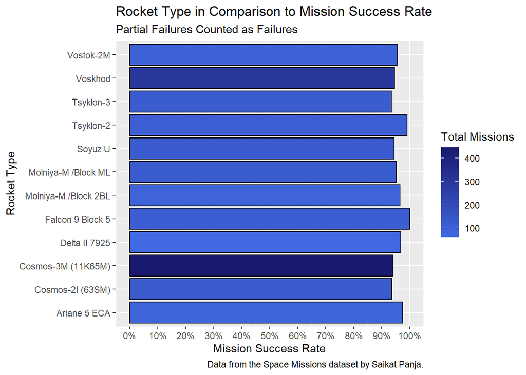

```r
## filtering rocket data
success_by_rocket <-
  space_data |>
    select(Rocket, MissionStatus
  ) |>
    mutate(
      success = MissionStatus == "Success"
  ) |>
  group_by(Rocket) |>
  summarize(
    success_rate = mean(success),
    missions = n()
  ) |>
  filter(missions >= 50) |>
  arrange(desc(success_rate)) |>

## producing bar graph
  ggplot(
    aes(
      x = Rocket,
      y = success_rate,
      fill = missions)
  ) +
  geom_col(color = "black") +
  scale_y_continuous(
    limits = c(0, 1),
    breaks = seq(0, 1, by = 0.1),
    labels = scales::percent
  ) +
  coord_flip() +
  scale_fill_gradient(
    low = "royalblue",
    high = "midnightblue"
  ) +
  labs(
    x = "Rocket Type",
    y = "Mission Success Rate",
    fill = "Total Missions",
    title = "Rocket Type in Comparison to Mission Success Rate",
    subtitle = "Partial Failures Counted as Failures",
    caption = "Data from the Space Missions dataset by Saikat Panja."
  )
success_by_rocket
```

> We determined that the reliability of individual, well-used rocket types would be made clear through comparison to mission success rate, represented on a bar graph. This visualization shows the reliability of various rocket types by comparing rocket type to mission success rate. Reliability is measured by the rate of mission success for each rocket. Rockets with fewer than fifty missions were excluded from the analysis to mitigate bias and to produce a more meaningful comparison, and partial failures were counted as full failures for simplicity.

## Reliability of Space Missions Over Time

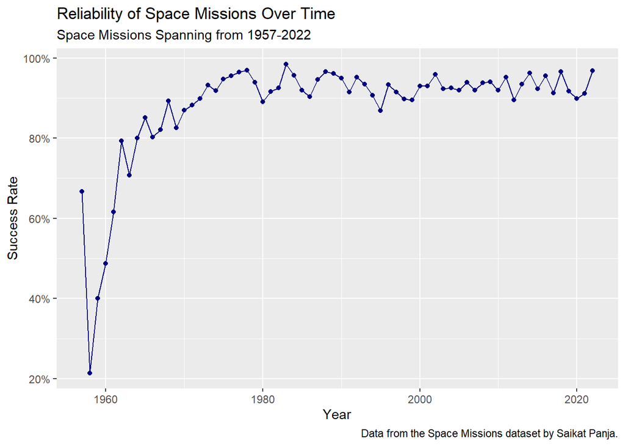

```r
## filtering rocket and mission data
reliability_graph <-
  space_data |>
  mutate(
  Year = year(Date),
  is_success = MissionStatus == "Success"
) |>
  group_by(Year) |>
  summarise(
    total = n(),
    successes = sum(is_success),
    success_rate = successes / total) |>

## producing line graph
  ggplot(
    aes(
      x = Year,
      y = success_rate)
    ) +
  geom_line(color = "navyblue") +
  geom_point(color = "navyblue") +
  scale_y_continuous(
   labels = scales::percent
  ) +
  labs(
    x = "Year",
    y = "Success Rate",
    title = "Reliability of Space Missions Over Time",
    subtitle = "Space Missions Spanning from 1957-2022",
    caption = "Data from the Space Missions dataset by Saikat Panja."
  )
reliability_graph
```

> This line graph shows space mission success rates over time, spanning from 1957 to 2022. This visualization was chosen to show improvements in space travel since its start over sixty years ago. Success rates were plotted as percentages and analyzed by year, allowing patterns of increasing dependability of space technology and mission coordination to be observed.

# Conclusions